# Tidy Models

Anwar Dahir

## Introduction

This R Markdown document demonstrates my abilities to use models for data analysis using a data set collected on crickets.

## What is that sound?

In this report, we examine what factors predict a cricket’s chirp rate.

```
##              species        temp            rate
##  O. exclamationis:14   Min.   :17.20   Min.   : 44.30
##  O. niveus       :17   1st Qu.:20.80   1st Qu.: 59.45
##                        Median :24.00   Median : 76.20
##                        Mean   :23.76   Mean   : 72.89
##                        3rd Qu.:26.35   3rd Qu.: 85.25
##                        Max.   :30.40   Max.   :101.70
```

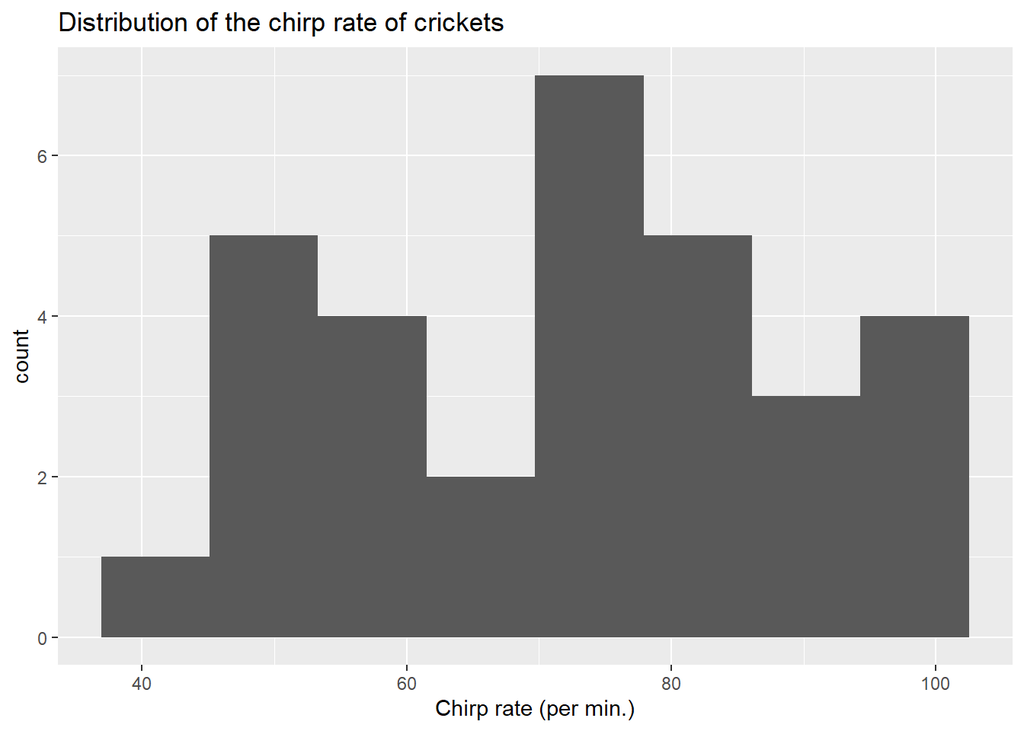

## Temperature affects chirp rate

Based on a scatter plot of temperature and chirping, it seems that as temperature increases, the rate of chirping also increases.

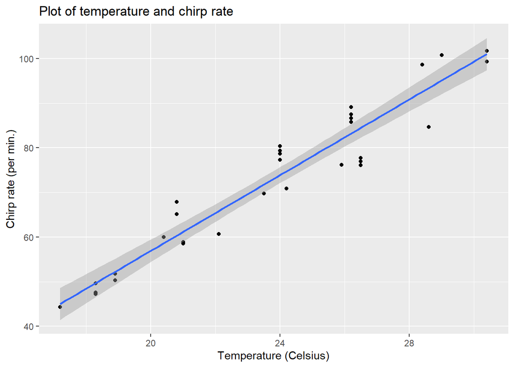

```
##
## Call:
## lm(formula = rate ~ temp, data = crickets)
##
## Residuals:
##     Min      1Q  Median      3Q     Max
## -8.7044 -2.5789 -0.4466  4.5353  7.5916
##
## Coefficients:
##             Estimate Std. Error t value Pr(>|t|)
## (Intercept) -27.9476     5.5937  -4.996 2.56e-05 ***
## temp          4.2431     0.2325  18.251  < 2e-16 ***
## ---
## Signif. codes:  0 '***' 0.001 '**' 0.01 '*' 0.05 '.' 0.1 ' ' 1
##
## Residual standard error: 4.868 on 29 degrees of freedom
## Multiple R-squared:  0.9199, Adjusted R-squared:  0.9171
## F-statistic: 333.1 on 1 and 29 DF,  p-value: < 2.2e-16
```

Based on a scatter plot of temperature and chirping and a correlation test, it seems that as temperature increases one degree, the rate of chirping increases about 4.2 chirps per minute.

## Species-specific effects of temperature on chirping

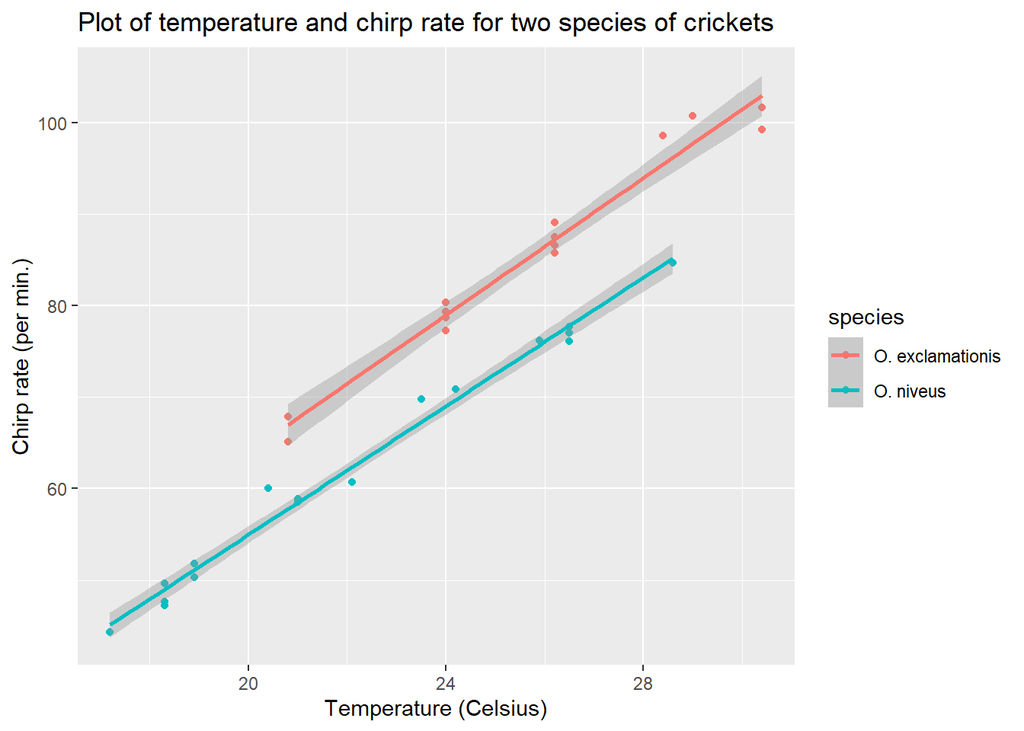

```
##
## Call:
## lm(formula = rate ~ temp + species, data = crickets)
##
## Residuals:
##     Min      1Q  Median      3Q     Max
## -3.0128 -1.1296 -0.3912  0.9650  3.7800
##
## Coefficients:
##                   Estimate Std. Error t value Pr(>|t|)
## (Intercept)       -7.21091    2.55094  -2.827  0.00858 **
## temp               3.60275    0.09729  37.032  < 2e-16 ***
## speciesO. niveus -10.06529    0.73526 -13.689 6.27e-14 ***
## ---
## Signif. codes:  0 '***' 0.001 '**' 0.01 '*' 0.05 '.' 0.1 ' ' 1
##
## Residual standard error: 1.786 on 28 degrees of freedom
## Multiple R-squared:  0.9896, Adjusted R-squared:  0.9888
## F-statistic:  1331 on 2 and 28 DF,  p-value: < 2.2e-16
```

The graph shows that for both type of species there is a positive relationship between temperature and chirp rate. The model summary shows that both the predictors are statistically significant and the R square for the model is 0.9896.

## Interactions

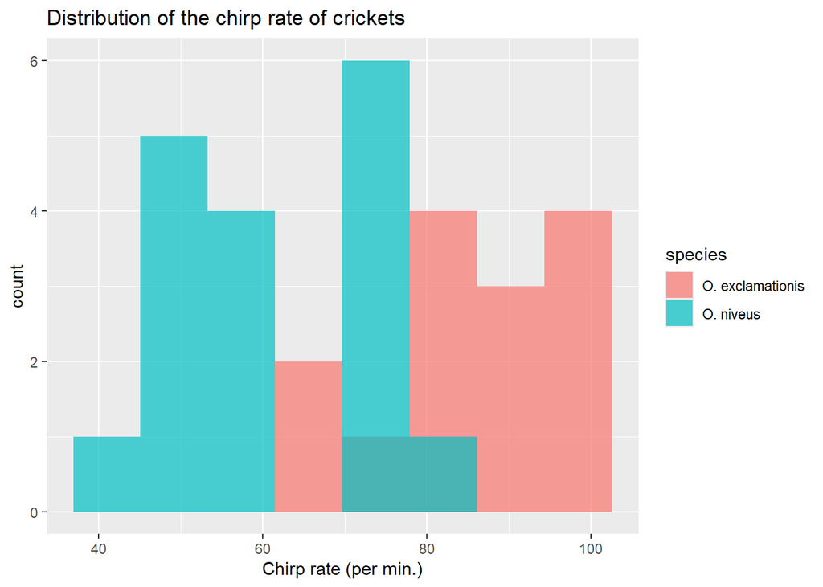

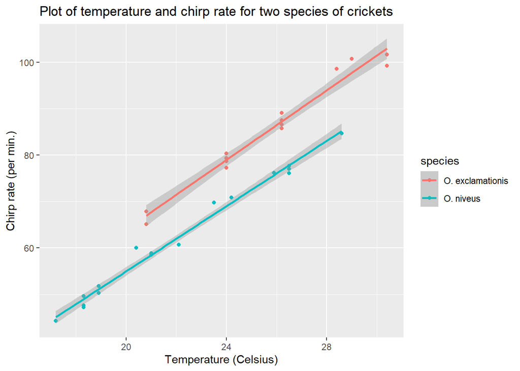

```
##
## Call:
## lm(formula = rate ~ temp + species + temp:species, data = crickets)
##
## Residuals:
##     Min      1Q  Median      3Q     Max
## -3.7031 -1.3417 -0.1235  0.8100  3.6330
##
## Coefficients:
##                       Estimate Std. Error t value Pr(>|t|)
## (Intercept)           -11.0408     4.1515  -2.659    0.013 *
## temp                    3.7514     0.1601  23.429   <2e-16 ***
## speciesO. niveus       -4.3484     4.9617  -0.876    0.389
## temp:speciesO. niveus  -0.2340     0.2009  -1.165    0.254
## ---
## Signif. codes:  0 '***' 0.001 '**' 0.01 '*' 0.05 '.' 0.1 ' ' 1
##
## Residual standard error: 1.775 on 27 degrees of freedom
## Multiple R-squared:  0.9901, Adjusted R-squared:  0.989
## F-statistic: 898.9 on 3 and 27 DF,  p-value: < 2.2e-16
```

|  | Res.Df | RSS | Df | Sum of Sq | F | Pr(>F) |
| --- | --- | --- | --- | --- | --- | --- |
| 1 | 28 | 89.34987 | NA | NA | NA | NA |
| 2 | 27 | 85.07409 | 1 | 4.275779 | 1.357006 | 0.2542464 |

The data is checked for ineractions but finally, it is decided to stay wit the original model.

# Diamonds Data Analysis

The scatter plot shows that the carat and price has a positive relationship while the boxplot shows that the average price is highest for premium cut.

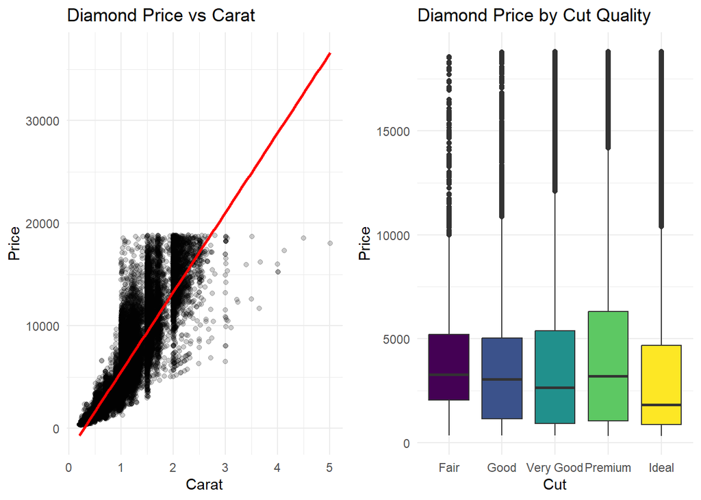

```r
diamonds <- ggplot2::diamonds

p1 <- ggplot(diamonds, aes(x = carat, y = price)) +
  geom_point(alpha = 0.2) +
  geom_smooth(method = "lm", color = "red") +
  labs(title = "Diamond Price vs Carat",
       x = "Carat",
       y = "Price") +
  theme_minimal()

p2 <- ggplot(diamonds, aes(x = cut, y = price, fill = cut)) +
  geom_boxplot() +
  labs(title = "Diamond Price by Cut Quality",
       x = "Cut",
       y = "Price") +
  theme_minimal() +
  theme(legend.position = "none")

gridExtra::grid.arrange(p1, p2, nrow = 1)
```

The correlation plot shows that all variables has strong positive correlation with rspect to price except depth and table.

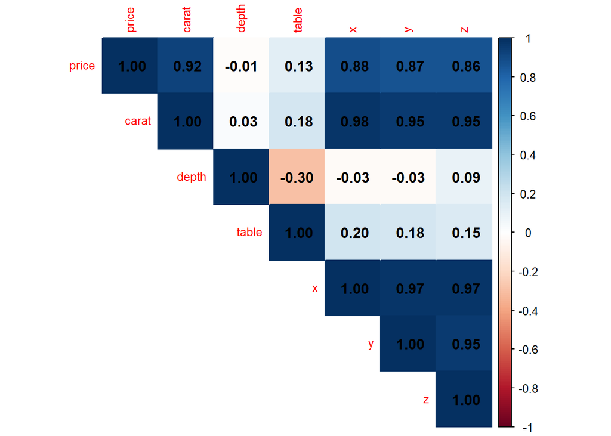

```r
# Select numeric variables
numeric_vars <- diamonds %>%
  select(price, carat, depth, table, x, y, z)

# Compute correlation matrix
cor_matrix <- cor(numeric_vars)

# Plot heatmap
corrplot::corrplot(cor_matrix, method = "color", type = "upper",
         tl.cex = 0.8, addCoef.col = "black")
```

The model is fitted with carat, cut, clarity and color as independent variables to predict the price. The model shows that the R square is 91.59%.

```r
# Using carat (continuous) + cut + clarity + color
model <- lm(price ~ carat + cut + clarity + color,
            data = diamonds)

# View model summary
summary(model)
```

```
##
## Call:
## lm(formula = price ~ carat + cut + clarity + color, data = diamonds)
##
## Residuals:
##      Min       1Q   Median       3Q      Max
## -16813.5   -680.4   -197.6    466.4  10394.9
##
## Coefficients:
##              Estimate Std. Error  t value Pr(>|t|)
## (Intercept) -3710.603     13.980 -265.414  < 2e-16 ***
## carat        8886.129     12.034  738.437  < 2e-16 ***
## cut.L         698.907     20.335   34.369  < 2e-16 ***
## cut.Q        -327.686     17.911  -18.295  < 2e-16 ***
## cut.C         180.565     15.557   11.607  < 2e-16 ***
## cut^4          -1.207     12.458   -0.097    0.923
## clarity.L    4217.535     30.831  136.794  < 2e-16 ***
## clarity.Q   -1832.406     28.827  -63.565  < 2e-16 ***
## clarity.C     923.273     24.679   37.411  < 2e-16 ***
## clarity^4    -361.995     19.739  -18.339  < 2e-16 ***
## clarity^5     216.616     16.109   13.447  < 2e-16 ***
## clarity^6       2.105     14.037    0.150    0.881
## clarity^7     110.340     12.383    8.910  < 2e-16 ***
## color.L     -1910.288     17.712 -107.853  < 2e-16 ***
## color.Q      -627.954     16.121  -38.952  < 2e-16 ***
## color.C      -171.960     15.070  -11.410  < 2e-16 ***
## color^4        21.678     13.840    1.566    0.117
## color^5       -85.943     13.076   -6.572 5.00e-11 ***
## color^6       -49.986     11.889   -4.205 2.62e-05 ***
## ---
## Signif. codes:  0 '***' 0.001 '**' 0.01 '*' 0.05 '.' 0.1 ' ' 1
##
## Residual standard error: 1157 on 53921 degrees of freedom
## Multiple R-squared:  0.9159, Adjusted R-squared:  0.9159
## F-statistic: 3.264e+04 on 18 and 53921 DF,  p-value: < 2.2e-16
```

Checking the assumptions of the model shows that the assumption of linearity and normality are violated.

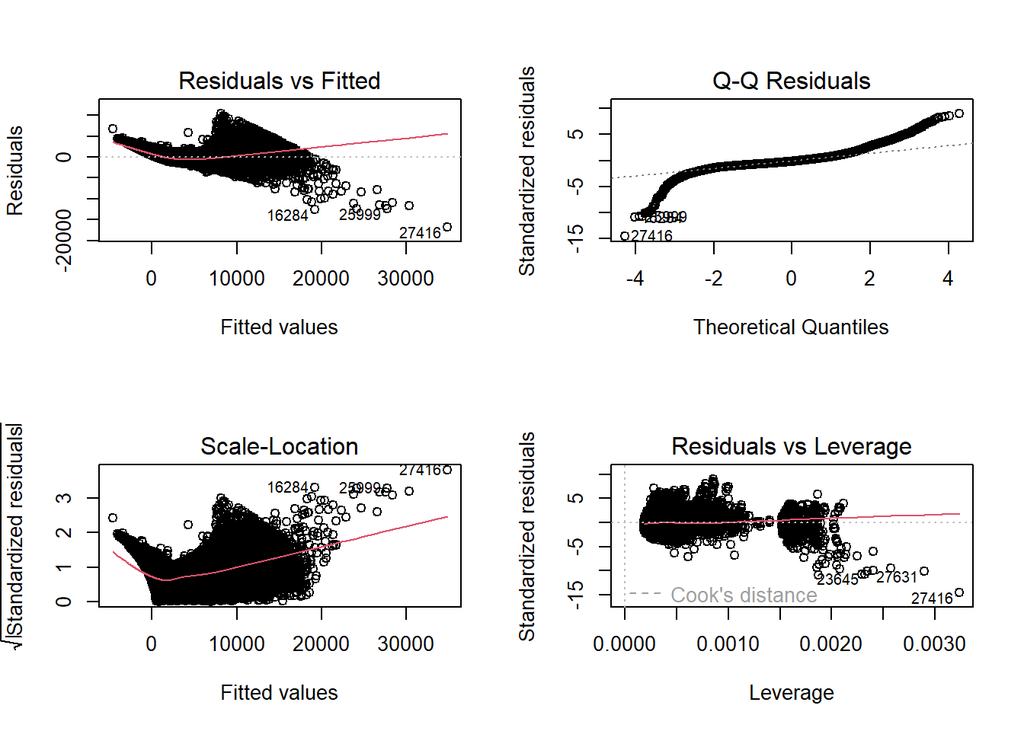

```r
# Check model diagnostics
par(mfrow = c(2,2))
plot(model)
```

This is the model with only numeric columns as the predictors. The model shows that except “z”, all predictors are statistically significant with R square of 85.92% for the model.

```r
model_numeric <- lm(price ~ carat + depth + table + x + y + z,
                    data = diamonds)

summary(model_numeric)
```

```
##
## Call:
## lm(formula = price ~ carat + depth + table + x + y + z, data = diamonds)
##
## Residuals:
##      Min       1Q   Median       3Q      Max
## -23878.2   -615.0    -50.7    347.9  12759.2
##
## Coefficients:
##              Estimate Std. Error t value Pr(>|t|)
## (Intercept) 20849.316    447.562  46.584  < 2e-16 ***
## carat       10686.309     63.201 169.085  < 2e-16 ***
## depth        -203.154      5.504 -36.910  < 2e-16 ***
## table        -102.446      3.084 -33.216  < 2e-16 ***
## x           -1315.668     43.070 -30.547  < 2e-16 ***
## y              66.322     25.523   2.599  0.00937 **
## z              41.628     44.305   0.940  0.34744
## ---
## Signif. codes:  0 '***' 0.001 '**' 0.01 '*' 0.05 '.' 0.1 ' ' 1
##
## Residual standard error: 1497 on 53933 degrees of freedom
## Multiple R-squared:  0.8592, Adjusted R-squared:  0.8592
## F-statistic: 5.486e+04 on 6 and 53933 DF,  p-value: < 2.2e-16
```